# PG2-Informe

#### **- Segundo paso: Validación**

**- Media ≅ Mediana**

$$(\overline {X}) ≅ Me$$

```r
# Vector con el primer y tercer cuartil
Cuartiles <- c(15,30)
# Número de datos
N <- length(Cuartiles)
# Suma de los datos
Suma <- sum(Cuartiles)
# Media aritmética
Meedia <- Suma / N
Meedia
```

```
## [1] 22.5
```

```r
# 10
```

```r
Tmax_estudio_digitalSort <- sort(datos_filtrados1$Tmax_estudio_digital)
Mediana <- median(Tmax_estudio_digitalSort)
Mediana
```

```
## [1] 20
```

#### **- Verificación de la Media y Mediana**

**- Media y mediana diferentes**

- Cómo podemos observar la media es 22.5 y la mediana es 20, por lo que podemos afirmar que no existe una curva normal, sin embargo, la mayor cantidad de nuestros encuestados respondieron que dedican entre 0 y 40 horas a la semana de tiempo máximo de estudio con dispositivos digitales, razón por la cuál decidimos reducir nuestra gráfica entre estos valores.

**- Reduccción de la gráfica**

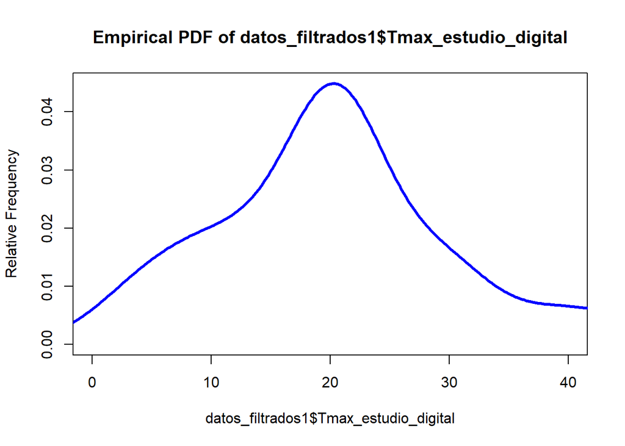

```r
library(EnvStats)

epdfPlot(datos_filtrados1$Tmax_estudio_digital, epdf.col = "blue",xlim=c(0,40))
```

**- Nueva validación de Media ≅ Mediana**

$$(\overline {X}) ≅ Me$$

```r
# Vector con el primer y tercer cuartil
Cuartiles <- c(0,40)
# Número de datos
N <- length(Cuartiles)
# Suma de los datos
Suma <- sum(Cuartiles)
# Media aritmética
Meedia <- Suma / N
Meedia
```

```
## [1] 20
```

```r
# 10
```

```r
Tmax_estudio_digitalSort <- sort(datos_filtrados1$Tmax_estudio_digital)
Mediana <- median(Tmax_estudio_digitalSort)
Mediana
```

```
## [1] 20
```

**- Desviación estándar**

$$Sd$$
- Para hallar la desviación estándar de una variable aleatoria Tmax_estudio_digital, usamos la función *sd*.

```r
sd(datos_filtrados1$Tmax_estudio_digital)
```

```
## [1] 14.41616
```

**Varianza**

$$V({X}) ≅ Sd^2(Tiempo de
max.estudiodigital)$$

- Para hallar la varianza de una variable aleatoria Tmax_estudio_digital, usamos la función *var*.

```r
var(datos_filtrados1$Tmax_estudio_digital)
```

```
## [1] 207.8256
```

**- Esperanza =**

$$E({X}) ≅
mean(Tmax.estudiodigital)$$

- Para hallar la esperanza de una variable aleatoria Tmax.estudiodigital, usamos la función *mean*.

```r
mean(datos_filtrados1$Tmax_estudio_digital)
```

```
## [1] 23.1411
```

**- Otra manera de validar la esperanza**

```r
esperanza <- sum(datos_filtrados1$Tmax_estudio_digital) / length(datos_filtrados1$Tmax_estudio_digital)
esperanza
```

```
## [1] 23.1411
```

```r
summary(datos_filtrados1$Tmax_estudio_digital)
```

```
##    Min. 1st Qu.  Median    Mean 3rd Qu.    Max.
##    0.00   15.00   20.00   23.14   30.00   72.00
```

#### **- Tercer paso**

Al validar nuestra variable aleatoria continua Tmax_estudio_digital como una distribución normal, tenemos que:

$$X ≈ N(µ,σ)$$

```r
U = mean(datos_filtrados1$Tmax_estudio_digital)
O = sd(datos_filtrados1$Tmax_estudio_digital)
U
```

```
## [1] 23.1411
```

```r
O
```

```
## [1] 14.41616
```

#### **- CUARTO PASO**

**Plateamos el experimento:** ¿Cuál es la probabilidad de que un estudiante estudie digital en un tiempo mayor a 30 minutos?

```r
mu_tmax <- mean(datos_filtrados1$Tmax_estudio_digital)
desviacion_tmax <- sd(datos_filtrados1$Tmax_estudio_digital)
prob_tmax_menor_30 <- pnorm(30, mean = mu_tmax, sd = desviacion_tmax, lower.tail = FALSE)
print(paste("Probabilidad de que Tmax_estudio_digital sea menor a 30 es:", round(prob_tmax_menor_30, 2)))
```

[output not shown]

```r
prob_conjunta <- prob_demora_mayor_10 * prob_tmax_menor_30
print(paste("Probabilidad conjunta de ambas condiciones es:", round(prob_conjunta, 3)))
```

```
## [1] "Probabilidad conjunta de ambas condiciones es: 0.134"
```